# Assignment 2

Conor McMahon

11/16/2021

# Data Description:

From the lab handout:

*Imagine we have the following data from Beijing . A survey was conducted of weekly work hours across 100 blocks in the city in February and once again in June of the same year. A power plant in region A was shut down in April. A random, representative sample of households was drawn in each block. We have data on average weekly work hours aggregated at the block level. The survey also collected data on visits to health clinics related to respiratory complaints. For each block we also have data on harmful particulate matter (PM 2.5) levels for the week preceding the survey collected from pollution monitoring stations. The blocks are split into two regions – Region A and Region B. The plant was located in proximity to the blocks in Region A. The Region B blocks are much further away from the plant. The data is available in the file assignment2.xls. The variables are: blockid – an identifier for city block; regionid - identifier for region in which block is located; month - survey month; PM – PM 2.5 level in ppm; resp – number of respiratory complaints per 10,000 people. Indicator variables were created for Treatment (Region A) and After (June). Using this data answer the following questions:*

# Part A - Summary Stats

First, we’ll estimate the average PM 2.5 particulate pollution levels in each region during February and June:

```r
# Load Input Data
beijing_data <- read_csv(here::here("assignment2_data.csv")) %>%
  janitor::clean_names()

# Generate and Display Summary Data
pm_summaries_regional <- beijing_data %>%
  group_by(regionid, month) %>%
  filter(month %in% c("Feb","June")) %>%
  summarize(pm_2p5_avg = mean(pm_2_5))
kbl(pm_summaries_regional) %>%
  kable_styling()
```

| regionid | month | pm_2p5_avg |
| --- | --- | --- |
| A | Feb | 7.345904 |
| A | June | 4.564302 |
| B | Feb | 5.494460 |
| B | June | 4.727070 |

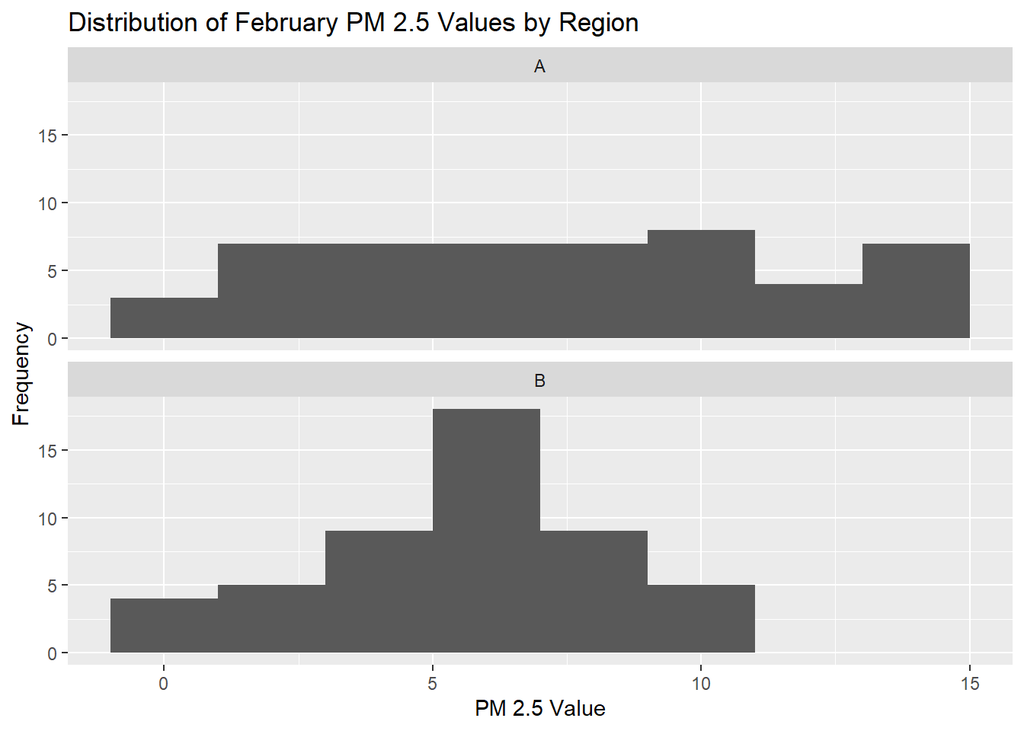

```r
# Visualize Distributions across Regions / Months
ggplot(beijing_data %>% filter(month=="Feb") %>% drop_na()) +
  geom_histogram(aes(x=pm_2_5), binwidth=2.0) +
  facet_wrap(~regionid, nrow=2) +
  ggtitle("Distribution of February PM 2.5 Values by Region") +
  xlab("PM 2.5 Value") +
  ylab("Frequency")
```

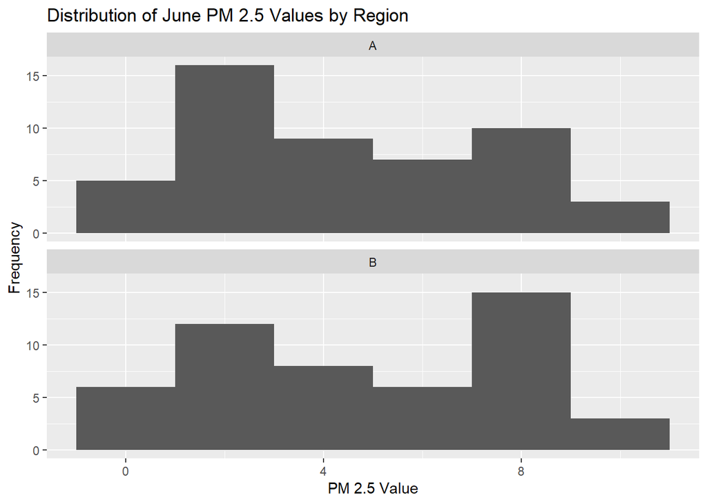

```r
ggplot(beijing_data %>% filter(month=="June") %>% drop_na()) +
  geom_histogram(aes(x=pm_2_5), binwidth=2.0) +
  facet_wrap(~regionid, nrow=2) +
  ggtitle("Distribution of June PM 2.5 Values by Region") +
  xlab("PM 2.5 Value") +
  ylab("Frequency")
```